# Proj1-JSON

David Ritchie

10/16/2019

# JSON files

## What is JSON?

JSON (JavaScript Object Notation) is a file that stores data structures in a JavaScript format which is a standard data interchange format. It is primarily used for transmitting data between a web appliation and a server. The files are text based and can be edited via a text editor.

There are may programs that open JSON files depending on a particular operating system. More about JSON files can be found at FileInfo. http://fileinfo.com/extension/json

## R packages that read in JSON

R has 3 major packages for reading in JSON files, as well as writing to a JSON file. rjson, jsonlite and rapidjsonr.  
rjson - reads in JSON array data to unnamed list and JSON objects to named lists. More can be learned at cran.r-project.org.https://cran.r-project.org/web/packages/rjson/rjson.pdf jsonlite - based on rjson but optimized for the web. Its strength is that it implements a bidirectional mapping, without the loss of type or infomation. This decreases the need for additional data manipulation/simplification. More can be learned at cran.r-project.org https://cran.r-project.org/web/packages/jsonlite/vignettes/json-aaquickstart.html or https://www.tutorialspoint.com/r/r_json_files.htm rapidjsonr - json parser and generator for C++. More can be learned at cran.r-project.org. https://cran.r-project.org/web/packages/rapidjsonr/rapidjsonr.pdf

When comparing rjson vs. jsonlite, the simplification of data during the read-in makes it a friendlier tool.

The following data example comes from https://www.sitepoint.com/database-json-file/ and a hierarchical structure and would require more manipulation due to the nesting structure. The ‘simplifyVector’ argument simplifies nested lists into vectors and dataframes.

```r
result <- read_json("C:/Users/User/Documents/Proj1DavidR/example2.json", simplifyVector = TRUE)
str(result)
```

```
## 'data.frame':    45 obs. of  5 variables:
##  $ _id         :'data.frame':    45 obs. of  1 variable:
##   ..$ $oid: chr  "5968dd23fc13ae04d9000001" "5968dd23fc13ae04d9000002" "5968dd23fc13ae04d9000003" "5968dd23fc13ae04d9000003" ...
##  $ product_name: chr  "sildenafil citrate" "Mountain Juniperus ashei" "Dextromathorphan HBr" "Dextromathorphan HBr" ...
##  $ supplier    : chr  "Wisozk Inc" "Keebler-Hilpert" "Schmitt-Weissnat" "Schmitt-Weissnat" ...
##  $ quantity    : int  261 292 211 211 211 211 211 211 211 211 ...
##  $ unit_cost   : chr  "10.47" "8.74" "20.53" "20.53" ...
```

The 2 main agruments on fromjson include: simplifyVector: which will simplify nested lists into vectors or dataframes. flatten: which automatically flattens nested data frames into a single non-nested data frame. Its defaulted as FALSE.

## What information can be gathered from the data?

Overall, the data is very limited. There are 5 variables with a total of 45 observations. The id, supplier and product name do not have much variation. There are 3 suppliers with corresponding product names and id. This was a random pull of data and this isn’t the best possible data to manipulate, but some days will be like this. There is a lot of duplication on on quantities and unit costs, which falls in line with what is happening in the overall set.

What’s the summary data related to cost?

```
##    Min. 1st Qu.  Median    Mean 3rd Qu.    Max.
##    8.74    8.74   10.47   12.91   20.53   20.53
```

What are the totals and averages for the numeric columns quantity and cost?

| Supplier | Product_Name | Total_Quantity | Avg_Quantity | Total_Cost | Avg_Cost |
| --- | --- | --- | --- | --- | --- |
| Keebler-Hilpert | Mountain Juniperus ashei | 3504 | 292 | 104.88 | 8.74 |
| Schmitt-Weissnat | Dextromathorphan HBr | 2743 | 211 | 266.89 | 20.53 |
| Wisozk Inc | sildenafil citrate | 5220 | 261 | 209.40 | 10.47 |

## Including Plots

Which supplier sends the most product?

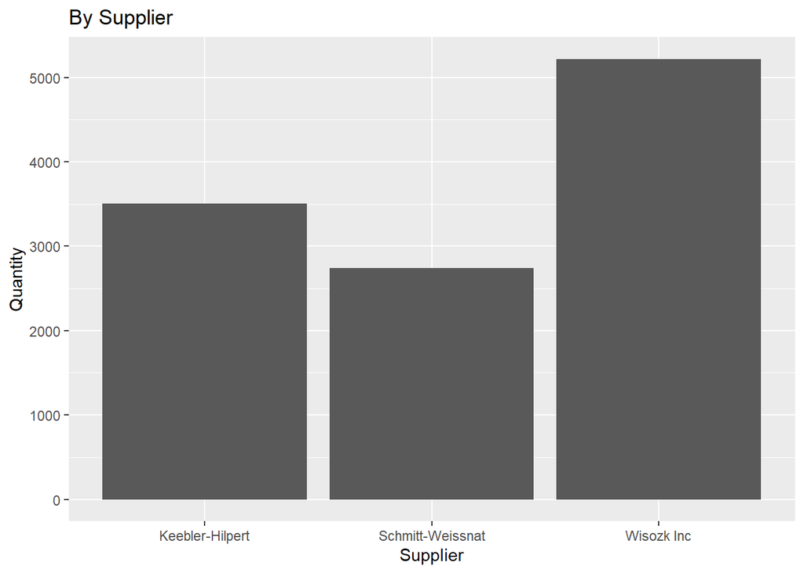

This bar graph supports the total quantity amount by supplier and is a easy to read quick reference vs. a table as see above.

Overall, the data is limited but this could be a good thing when looking at a JSON file for the first time.